# Lab 8: Two-Way Mixed ANOVA

## 1. Introduction

This tutorial covers how to run two-way within-subjects ANOVA.

We will use data from your textbook (see [‘Support Materials’ on the textbook webpage](https://www.routledge.com/Design-and-Analysis-in-Educational-Research-ANOVA-Designs-in-SPSS/Strunk-Mwavita/p/book/9781138361164)) (Shannonhouse et al. 2017). For your Lab 8 assignment, you will use the data provided on Canvas.

### 1.2 Background

In this article, the authors report on an experimental project to improve college and university staff attitudes and competencies about suicide and suicide prevention. The authors randomly assigned participants to receive suicide intervention training or to be on a waitlist for training (with waitlist participants serving as the control group). All participants completed a pre-test set of surveys and a post-test set of surveys.

The authors tested several outcomes, but in this case study, we focus on one: attitudes about suicide.

**Research Question**

Related to attitudes about suicide, the research question was:

*Was there a difference in attitudes about suicide based on the interaction of pre- versus post-test and placement in the experimental versus control groups?*

## 2. Data Preparation

Like for repeated measures (within-subjects), we have to start by making sure our data are properly organized for a mixed ANOVA design.

```r
# Importing the data
needs(tidyverse, rio, here, knitr, kableExtra, misty, janitor, rstatix, psych, misty, car, effectsize, MOTE, pwr2, Superpower)
df <- misty::read.sav(here("kamden-mwavita_data/mixed ANOVA - Shannonhouse et al.sav"), use.value.labels = TRUE) %>%
  clean_names()
```

Let’s take a look at our data:

```r
head(df)
```

```
##    pre_aos post_aos   group
## 1 17.92370 22.96400 Control
## 2 20.64179 20.69694 Control
## 3 20.07656 17.54743 Control
## 4 18.18248 18.47633 Control
## 5 15.95838 19.49510 Control
## 6 14.96571 16.40817 Control
```

### 2.1 Preparing Variables and Labels

Add in an ID column, if needed.

```r
df <- df %>%
  rowid_to_column("id")
head(df)
```

```
##   id  pre_aos post_aos   group
## 1  1 17.92370 22.96400 Control
## 2  2 20.64179 20.69694 Control
## 3  3 20.07656 17.54743 Control
## 4  4 18.18248 18.47633 Control
## 5  5 15.95838 19.49510 Control
## 6  6 14.96571 16.40817 Control
```

### 2.2 Pivoting the Data from ‘Wide’ to ‘Long’

So, here are the arguments the `pivot_longer` function will take in this case:

- `cols =` : Since we are pivoting only the test scores, we will select those columns only (`c(pre_aos, post_aos)`)
- `names_to =` : The names are a combination of the pre- and post-test scores, so we can write `timepoint`.
- `values_to =` : These are where the all the scores actually go, so we can call this new column `score`.

This is what it looks like all together:

```r
df <- df %>%
  pivot_longer(cols = c(pre_aos, post_aos),
               names_to = "timepoint",
               values_to = "score")

# Let's check if it worked:
head(df)
```

```
## # A tibble: 6 × 4
##      id group   timepoint score
##   <int> <fct>   <chr>     <dbl>
## 1     1 Control pre_aos    17.9
## 2     1 Control post_aos   23.0
## 3     2 Control pre_aos    20.6
## 4     2 Control post_aos   20.7
## 5     3 Control pre_aos    20.1
## 6     3 Control post_aos   17.5
```

Now we have one column for student id, one for group, one for timepoint, and one final one for the test score.

We can make the data a little more clean by making the levels in the group column into lowercase/rename the levels. Also group is a bit of a confusing variable name, since R uses `group` as an argument in ggplot and other functions.

```r
df <- df %>%
  rename(sample_group = group) %>%
  mutate(sample_group = case_when(sample_group == "Control" ~ "control",
                                  sample_group == "Experimental" ~ "experiment"))
head(df)
```

```
## # A tibble: 6 × 4
##      id sample_group timepoint score
##   <int> <chr>        <chr>     <dbl>
## 1     1 control      pre_aos    17.9
## 2     1 control      post_aos   23.0
## 3     2 control      pre_aos    20.6
## 4     2 control      post_aos   20.7
## 5     3 control      pre_aos    20.1
## 6     3 control      post_aos   17.5
```

### 2.3 Checking Variable Types

Now, we need to check that each variable is the right data type.

```r
str(df)
```

```
## tibble [144 × 4] (S3: tbl_df/tbl/data.frame)
##  $ id          : int [1:144] 1 1 2 2 3 3 4 4 5 5 ...
##  $ sample_group: chr [1:144] "control" "control" "control" "control" ...
##  $ timepoint   : chr [1:144] "pre_aos" "post_aos" "pre_aos" "post_aos" ...
##  $ score       : num [1:144] 17.9 23 20.6 20.7 20.1 ...
```

The ID variable, group variable, and timepoint variable should all be factors.

```r
factor_cols <- c("id", "sample_group", "timepoint") #list all the columns that should be factors here
df[factor_cols] <- lapply(df[factor_cols], as.factor) #apply the "as.factor" function to all of them

str(df) #it worked!
```

```
## tibble [144 × 4] (S3: tbl_df/tbl/data.frame)
##  $ id          : Factor w/ 72 levels "1","2","3","4",..: 1 1 2 2 3 3 4 4 5 5 ...
##  $ sample_group: Factor w/ 2 levels "control","experiment": 1 1 1 1 1 1 1 1 1 1 ...
##  $ timepoint   : Factor w/ 2 levels "post_aos","pre_aos": 2 1 2 1 2 1 2 1 2 1 ...
##  $ score       : num [1:144] 17.9 23 20.6 20.7 20.1 ...
```

Reminder – the function you used above is called `lapply()` that takes a list, applies a function to it, and returns a list. Since a data frame is a type of list, `lapply()` works really well if you are trying to apply a function to multiple columns at once.

Since pre-tests come before post-tests, we will reorder the levels. See lab 6 and 7 for more information about `lapply()` and `factor()`.

```r
df$timepoint <- factor(df$timepoint, levels =  c("pre_aos", "post_aos"))

str(df$timepoint) #it worked!
```

```
##  Factor w/ 2 levels "pre_aos","post_aos": 1 2 1 2 1 2 1 2 1 2 ...
```

## 3. Data Exploration and Assumptions

As usual, we will want to assess our data using descriptive statistics and graphical displays. See the following sections for methods to evaluate your data and whether they meet the assumptions of mixed ANOVA designs.

### 3.1 Descriptive Statistics

We can see the overall distribution using `describe()`, focusing on the values for our DV (`score`)

```r
describe(df)
```

```
##               vars   n  mean    sd median trimmed   mad   min   max range  skew
## id*              1 144 36.50 20.86  36.50   36.50 26.69  1.00 72.00 71.00  0.00
## sample_group*    2 144  1.65  0.48   2.00    1.69  0.00  1.00  2.00  1.00 -0.64
## timepoint*       3 144  1.50  0.50   1.50    1.50  0.74  1.00  2.00  1.00  0.00
## score            4 144 20.85  2.82  20.94   20.85  3.00 14.97 26.92 11.95 -0.01
##               kurtosis   se
## id*              -1.23 1.74
## sample_group*    -1.61 0.04
## timepoint*       -2.01 0.04
## score            -0.80 0.23
```

We can also look at more helpful statistics with `describeBy()`, examining scores by test_type and/or by group.

```r
describeBy(df, group = "sample_group")
```

```
##
##  Descriptive statistics by group
## sample_group: control
##               vars  n  mean   sd median trimmed  mad   min   max range skew
## id*              1 50 13.00 7.28  13.00    13.0 8.90  1.00 25.00 24.00 0.00
## sample_group*    2 50  1.00 0.00   1.00     1.0 0.00  1.00  1.00  0.00  NaN
## timepoint*       3 50  1.50 0.51   1.50     1.5 0.74  1.00  2.00  1.00 0.00
## score            4 50 19.24 2.20  19.13    19.2 2.29 14.97 25.15 10.18 0.22
##               kurtosis   se
## id*              -1.27 1.03
## sample_group*      NaN 0.00
## timepoint*       -2.04 0.07
## score            -0.32 0.31
## ------------------------------------------------------------
## sample_group: experiment
##               vars  n  mean    sd median trimmed   mad  min   max range  skew
## id*              1 94 49.00 13.64  49.00   49.00 17.79 26.0 72.00 46.00  0.00
## sample_group*    2 94  2.00  0.00   2.00    2.00  0.00  2.0  2.00  0.00   NaN
## timepoint*       3 94  1.50  0.50   1.50    1.50  0.74  1.0  2.00  1.00  0.00
## score            4 94 21.71  2.74  22.15   21.82  2.76 15.2 26.92 11.72 -0.34
##               kurtosis   se
## id*              -1.24 1.41
## sample_group*      NaN 0.00
## timepoint*       -2.02 0.05
## score            -0.61 0.28
```

### 3.2 Assessing Distribution

You can start with a simple histogram to assess the distribution of our DV.

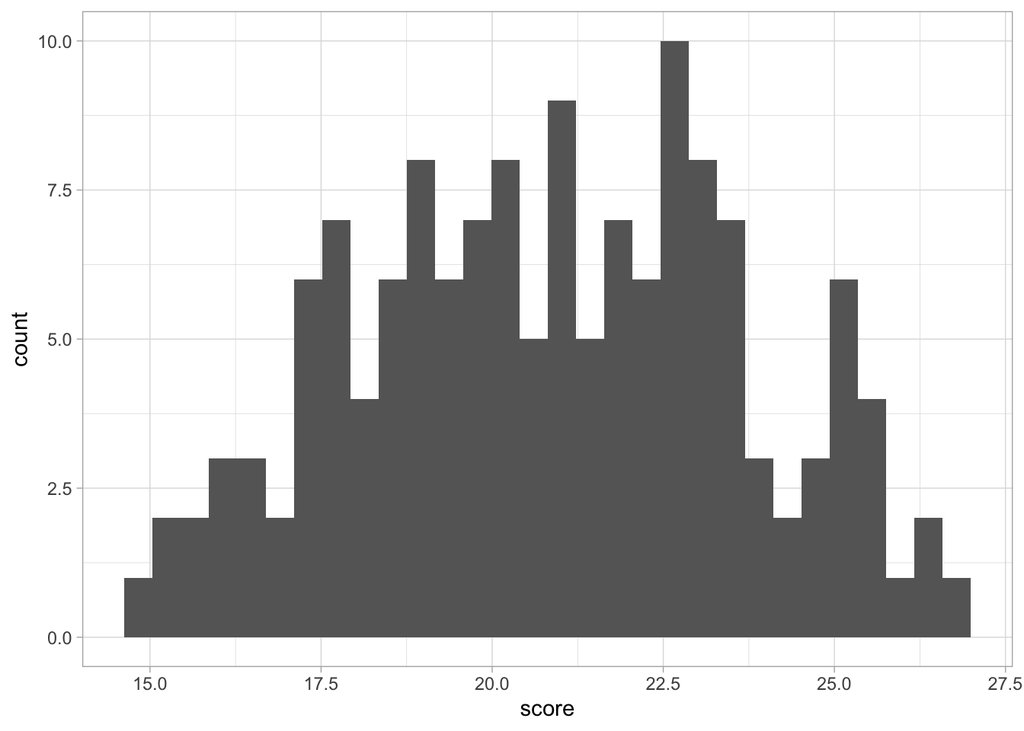

```r
ggplot(df, aes(x = score)) +
  geom_histogram(fill = "gray40") +
  theme_light()
```

#### 3.2.a QQ plot

Create your Quantile-Quantile (QQ) plot with the code below. If our DV is normally distributed, then the points on the Q-Q plot will perfectly lie on a straight line (i.e., y = x).

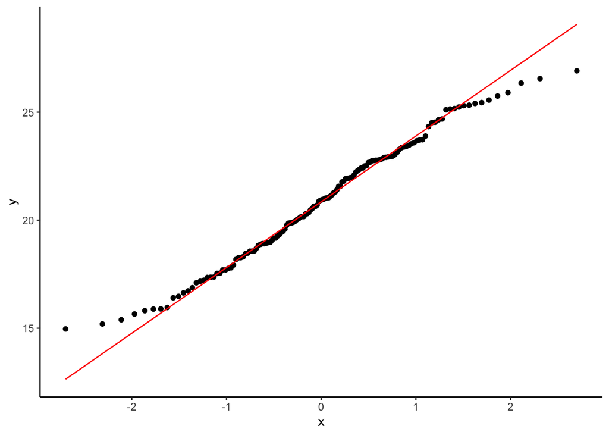

```r
df %>%
  ggplot(aes(sample = score)) +
    stat_qq()+
    stat_qq_line(color = "red") +
    theme_classic()
```

#### 3.2.b Boxplots

Let’s use boxplots to look at the score distributions.

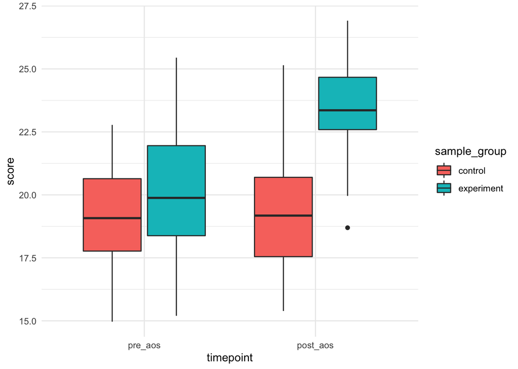

```r
df %>%
  ggplot(aes(x = timepoint, y = score)) +
  geom_boxplot(aes(fill = sample_group)) + #this groups the boxplots so you can see comparisons across both groups. can also use "group = timepoint" if you don't want colors
  theme_minimal()
```

### 3.4 Homogeneity of variance

```r
df %>%
  group_by(timepoint) %>% # grouping data to have a levene's test per level of timepoint variable
  levene_test(score ~ sample_group) #`levene_test()` from `rstatix` package
```

```
## # A tibble: 2 × 5
##   timepoint   df1   df2 statistic     p
##   <fct>     <int> <int>     <dbl> <dbl>
## 1 pre_aos       1    70     0.615 0.436
## 2 post_aos      1    70     1.42  0.237
```

To meet this assumption, Levene’s test must be passed (i.e., *p* > .05) for each level. Recall that the null hypothesis is that the variances are equal, so the assumption is tenable when *p* > .05.

### 3.5 Sphericity

As the data set for this tutorial only has two levels per variable (2x2 ANOVA), the sphericity assumption is not applicable. As you might recall, the test for sphericity only applies when there are 3+ levels to you IV, and the ANOVA output does not include Mauchly’s Test.

*However*, the data for the Lab 8 assignment, just like the Lab 7 assignment, include a variable with three levels. This means that you do need to test the sphericity assumption. In addition, since this is a two-way rather than a one-way, you will need to examine the assumption for both the main effect and the interaction effect.

For interpreting the ANOVA output, refer to Lab 6 tutorial, where the ANOVA output has three sections: (1) Univariate Type III Repeated-Measures ANOVA Assuming Sphericity, (2) Mauchly Tests for Sphericity, and (3) Greenhouse-Geisser and Huynh-Feldt Corrections for Departure from Sphericity.

If *p* < .05 for Mauchly’s (meaning your sphericity assumption was violated), you will use the corresponding test statistic from the third section for the main effect/interaction.

## 4. Conducting Two-Way Within-Subjects ANOVA

We will still use `aov_car`, part of the `afex` package. We need to specify our ID variable and the independent variables within the `Error()` term.

### 4.1 Creating ANOVA Model

The general structure for two-way within-subjects is as follows:

**DV ~ IV1 + IV2 + IV1:IV2 + Error(ID/IV1)**

where IV1 = within-subjects variable, and IV2 = between-subjects variable

Plug in the respective values into the model:

```r
needs(afex)
m1 <- afex::aov_car(score ~ timepoint + sample_group + timepoint:sample_group + Error(id/timepoint), data=df, include_aov = F)
```

```
## Contrasts set to contr.sum for the following variables: sample_group
```

```r
summary(m1)
```

```
##
## Univariate Type III Repeated-Measures ANOVA Assuming Sphericity
##
##                        Sum Sq num Df Error SS den Df   F value    Pr(>F)
## (Intercept)             54732      1   350.92     70 10917.682 < 2.2e-16 ***
## sample_group              199      1   350.92     70    39.721 2.274e-08 ***
## timepoint                  89      1   317.83     70    19.570 3.478e-05 ***
## sample_group:timepoint     98      1   317.83     70    21.514 1.588e-05 ***
## ---
## Signif. codes:  0 '***' 0.001 '**' 0.01 '*' 0.05 '.' 0.1 ' ' 1
```

#### 4.1.a Effect size: Variation ($\omega^{2}$)

Given that $\omega^{2}$ is robust to bias associated with sample size, we will use this as our preferred effect size to describe the proportion of explained variance in our model. The following code provides partial omega squared estimates ($\omega_p^{2}$) for each IV in the model.

```r
# using package `effectsize`
omega_squared(m1)
```

```
## # Effect Size for ANOVA (Type III)
##
## Parameter              | Omega2 (partial) |       95% CI
## --------------------------------------------------------
## sample_group           |             0.35 | [0.21, 1.00]
## timepoint              |             0.11 | [0.02, 1.00]
## sample_group:timepoint |             0.12 | [0.03, 1.00]
##
## - One-sided CIs: upper bound fixed at (1).
```

### 4.2 Displaying Means

Since we don’t see the actual means in the ANOVA output, we can visualize those below, by sample_group and by timepoint.

```r
means <- df %>%
  group_by(timepoint, sample_group) %>%
  summarise(score = mean(score))
```

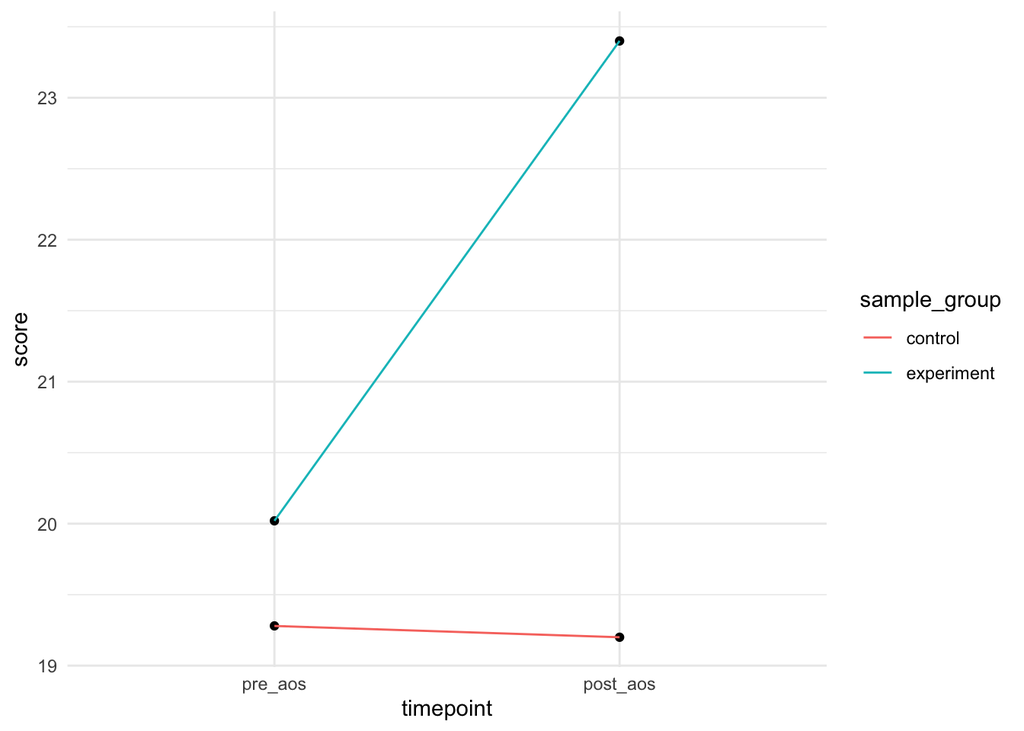

```r
ggplot(means, aes(x = timepoint, y = score, group = sample_group)) +
  geom_point() +
  geom_line(aes(color = sample_group)) +
  theme_minimal()
```

### 4.4 Interpreting Mixed ANOVA Results

There was a significant interaction effect between treatment groups and timepoint (*F*(1, 70) = 21.51, *p* < .001), where the difference in scores between pre- and post-test accounted for 12% of the overall variance in scores ($\omega_p^{2}$ = .12). Specifically, the suicide and suicide prevention attitudes and competencies improved significantly more over time for college and university staff who received suicide intervention training ($M_{pre-test}$ = 20.0, $M_{post-test}$ = 23.4) compared to their peers on the waitlist, whose attitudes and competencies scores did not change ($M_{pre-test}$ = 19.3, $M_{post-test}$ = 19.2).

## 5. Running Post-Hoc Pairwise Comparisons and Custom Contrasts

The following code will guide you through running custom contrasts for your future analyses, but are somewhat redundant for the 2x2 mixed ANOVA we ran in this tutorial.

### 5.1 Pairwise Comparisons

First, run `emmeans()` to see the order of the levels, estimates of the differences between the levels, and corresponding p-values and t-statistics.

```r
needs(emmeans)
em <- emmeans(m1, ~sample_group*timepoint)
pairs(em)
```

```
##  contrast                                 estimate    SE df t.ratio p.value
##  control pre_aos - experiment pre_aos        -0.74 0.587 70  -1.260  0.5910
##  control pre_aos - control post_aos           0.08 0.603 70   0.133  0.9992
##  control pre_aos - experiment post_aos       -4.12 0.556 70  -7.416  <.0001
##  experiment pre_aos - control post_aos        0.82 0.526 70   1.559  0.4088
##  experiment pre_aos - experiment post_aos    -3.38 0.440 70  -7.690  <.0001
##  control post_aos - experiment post_aos      -4.20 0.491 70  -8.562  <.0001
##
## P value adjustment: tukey method for comparing a family of 4 estimates
```

From here, we can see that control and experiment conditions are significantly different from each other for the post-test. Also, we can see for the experiment condition, the pre- and post-test scores are significantly different.

### 5.2 Creating Custom Contrasts

To illustrate and interpret a custom contrast for a two-way mixed ANOVA, we will code a contrast for the same interaction we had in the ANOVA model. So our research question is, “To what extent does participating in the suicide prevention intervention improve suicide and suicide prevention attitudes and competencies among college and university staff over time (pre- vs. post-test)?

The following code is for the custom contrast and the variation-based effect size ($\omega^{2}$):

```r
em # look at order of factors to specify coding
```

```
##  sample_group timepoint emmean    SE df lower.CL upper.CL
##  control      pre_aos     19.3 0.474 70     18.3     20.2
##  experiment   pre_aos     20.0 0.346 70     19.3     20.7
##  control      post_aos    19.2 0.396 70     18.4     20.0
##  experiment   post_aos    23.4 0.289 70     22.8     24.0
##
## Confidence level used: 0.95
```

```r
contrasts <- list(
  hyp1 = c(1, -1, -1, 1)
)
contrast(em, contrasts)
```

```
##  contrast estimate    SE df t.ratio p.value
##  hyp1         3.46 0.746 70   4.638  <.0001
```

```r
#Let's calculate effect size with Omega
# First turn t-ratio into F-ratio by squaring it: t^2 = F
# (4.639)^2
# Fvalue = 21.52032

# Second, put in values from the contrast output accordingly:
omega.F(dfm = 1, dfe = 70,
      Fvalue = 21.52032, n = 144,
      a = .025) # Correct for multiple comparisons (2 tests), so p-adjust is .05/2 = .025
```

```
## $omega
## [1] 0.1247282
##
## $omegalow
## [1] 0.009476689
##
## $omegahigh
## [1] 0.315247
##
## $dfm
## [1] 1
##
## $dfe
## [1] 70
##
## $F
## [1] 21.52032
##
## $p
## [1] 1.58367e-05
##
## $estimate
## [1] "$\\omega^2$ = 0.12, 97.5\\% CI [0.01, 0.32]"
##
## $statistic
## [1] "$F$(1, 70) = 21.52, $p$ < .001"
```

As expected, we find a significant pairwise contrast effect. This interaction contrast is interpreted the same way as the interaction effect above in section *4.4 Interpreting Mixed ANOVA Results*, and the statistics (e.g., $F$, $\omega^{2}$) should be virtually the same.